# data607_assignment7

## Extended analysis on *The Scarlet Letter*

Determining the gutenberg_id from the *gutenberg_works()* based on the title name given. We can look up for the *gutenbergr_id* from *gutenberg_works* or *gutenberg_metadata*.

```r
library("gutenbergr")

gutenberg_works() |>
  filter(title == "The Scarlet Letter")
```

```
## # A tibble: 1 × 8
##   gutenberg_id title              author  guten…¹ langu…² guten…³ rights has_t…⁴
##          <int> <chr>              <chr>     <int> <chr>   <chr>   <chr>  <lgl>
## 1           33 The Scarlet Letter Hawtho…      28 en      Movie … Publi… TRUE
## # … with abbreviated variable names ¹gutenberg_author_id, ²language,
## #   ³gutenberg_bookshelf, ⁴has_text
```

Downloading the *The Scarlet Letter* from *gutenberg_download()*

```r
scarlett_letter <- gutenberg_download(33)
```

```
## Determining mirror for Project Gutenberg from http://www.gutenberg.org/robot/harvest
```

```
## Using mirror http://aleph.gutenberg.org
```

```r
# assigning only text column values to text variable
text <- tibble(line = 1:nrow(scarlett_letter), scarlett_letter$text)

colnames(text) <- c('lines', 'text')


clean_book <- text |>
  unnest_tokens(word, text) #splits a columns into tokens

#counting list of positive words
clean_book |>
  inner_join(get_sentiments("bing")) |>
  count(word, sort = TRUE)
```

```
## # A tibble: 1,561 × 2
##    word        n
##    <chr>   <int>
##  1 like      143
##  2 good      120
##  3 well       79
##  4 better     64
##  5 great      62
##  6 smile      51
##  7 wild       49
##  8 strange    45
##  9 poor       44
## 10 sin        44
## # … with 1,551 more rows
## # ℹ Use `print(n = ...)` to see more rows
```

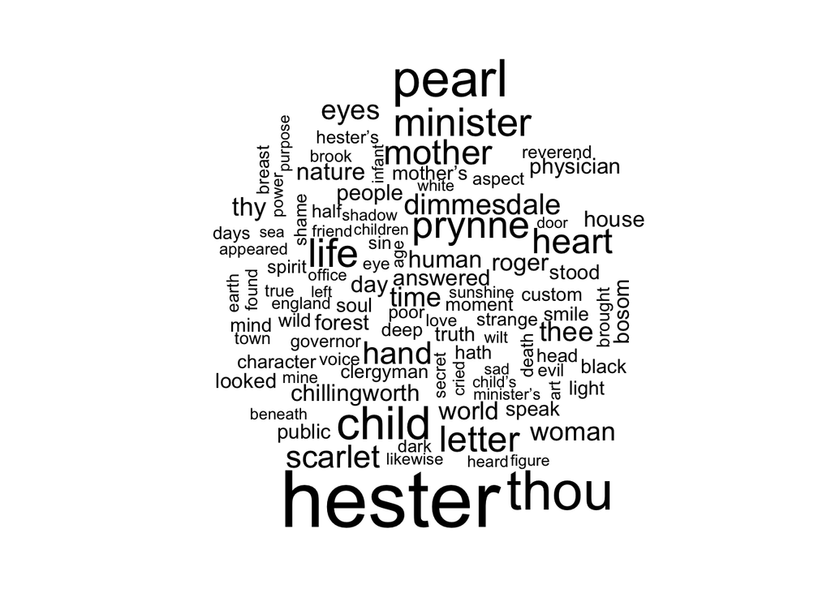

```r
#counting and forming workcloud postive words
clean_book |>
  anti_join(stop_words) |>
  count(word) |>
  with(wordcloud(word, n, max.words = 100))
```

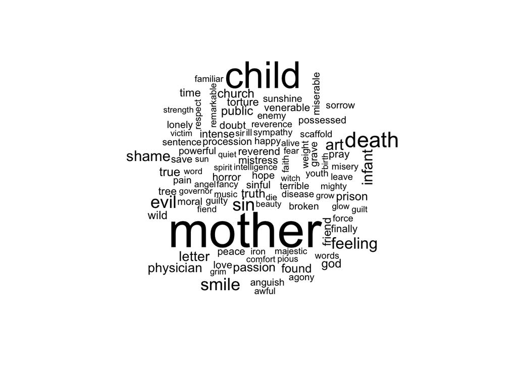

```r
#creating wordcloud for negative words
clean_book |>
  inner_join(get_sentiments("nrc")) |>
  anti_join(stop_words) |>
  count(word) |>
  with(wordcloud(word, n, max.words = 100))
```

```r
bing_word_counts <- clean_book %>%
  inner_join(get_sentiments("bing")) %>%
  count(word, sentiment, sort=TRUE)
```

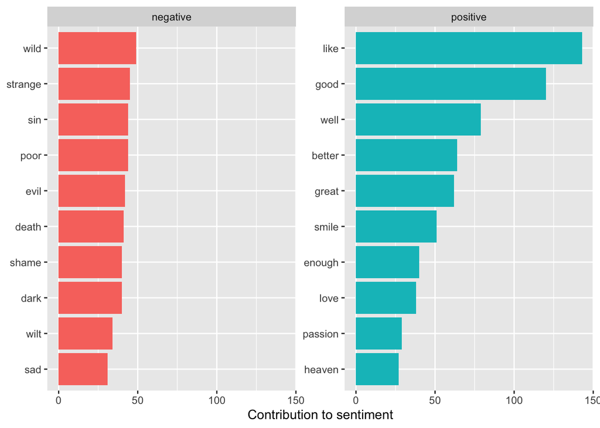

```r
bing_word_counts %>%
  group_by(sentiment) %>%
  top_n(10) %>%
  ggplot(aes(reorder(word, n), n, fill = sentiment)) +
  geom_bar(stat = "identity", show.legend = FALSE) +
  facet_wrap(~sentiment, scales = "free_y") +
  labs(y = "Contribution to sentiment", x = NULL) +
  coord_flip()
```

## Conclusion

I haven’t read **The Scarlet Letter** but the description of the book explains about regrets of the narrator. First I thought there would be plenty of negative emotions across the book but it seems like there are more positive words than expected within *top 10* rows.

Reference:

David Robinson, J. S. (n.d.). 2 Sentiment analysis with tidy data | Text Mining with R. 2 Sentiment Analysis With Tidy Data | Text Mining With R. Retrieved November 6, 2022, from https://www.tidytextmining.com/sentiment.html